# Annotated S4

# Generating Extremely Long Sequences in JAX

[Sasha Rush](http://rush-nlp.com/) (@srush_nlp) with [Sidd Karamcheti](https://www.siddkaramcheti.com/)

https://github.com/srush/annotated-s4

Based on research by Albert Gu, Karan Goel, and Christopher Ré.

# Intro

## The Transformer Weakness

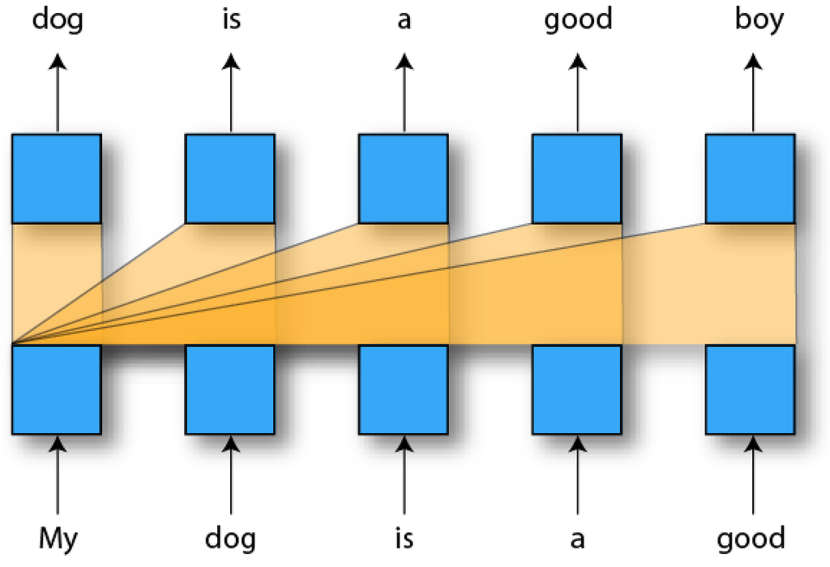

- Scales $O(L^2)$ with length $L$.

## Recurrent Neural Networks (RNN)

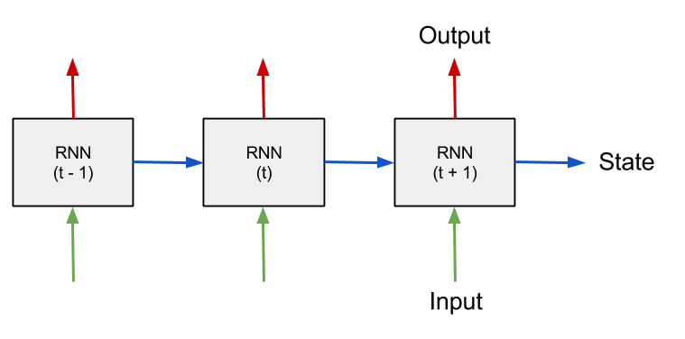

- Scales $O(L)$ with length $L$.

## Long Range Arena

- A benchmark of extremely long sequence tasks (up to 16k tokens)

[figure not shown]

## Linearized Images

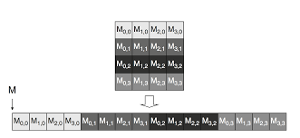

## Path-X

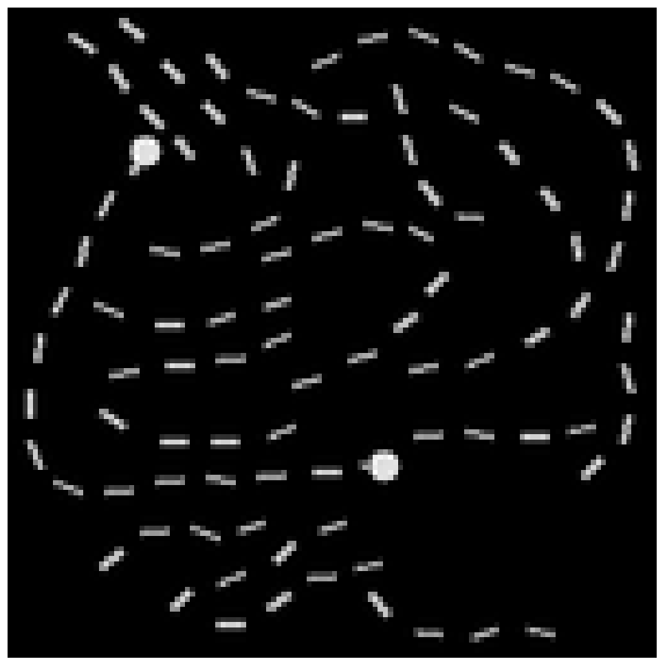

- Classification problem on linearized (one pixel at a time) image sequence.

# Method

## [Efficiently Modeling Long Sequences with Structured State Spaces](https://arxiv.org/abs/2111.00396)

Albert Gu, Karan Goel, and Christopher Ré.

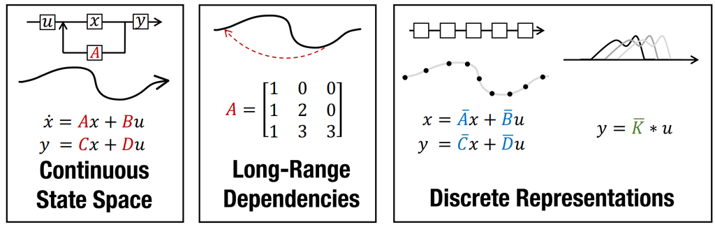

## Punchline

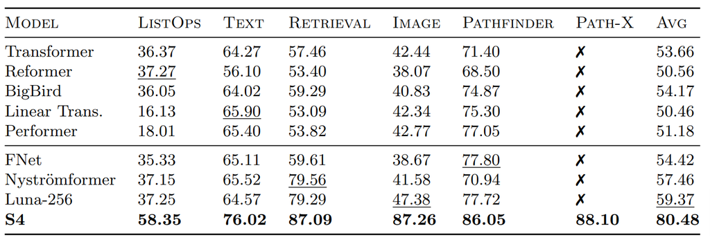

# [The Annotated S4](https://srush.github.io/annotated-s4/)

## Image Generation

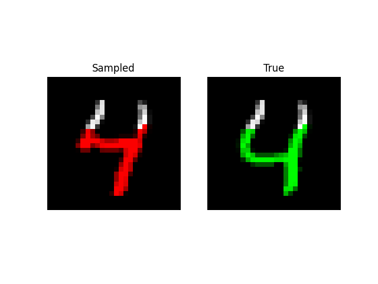

## Speech Generation

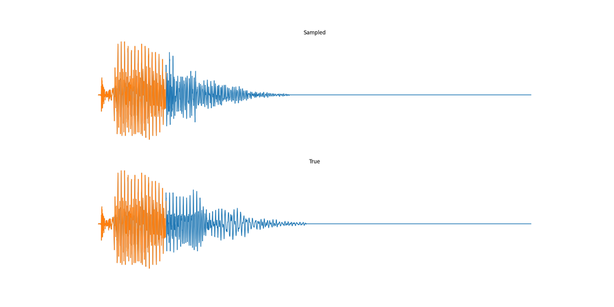

# Part 1: SSM

## State Space Models (SSM)

- A [state space model](https://en.wikipedia.org/wiki/State-space_representation) maps a 1-D input signal $u(t)$ to an $N$-D latent state $x(t)$ before projecting to a 1-D output signal $y(t)$.

$$\begin{aligned}
x'(t) &= \boldsymbol{A}x(t) + \boldsymbol{B}u(t) \\
y(t) &= \boldsymbol{C}x(t)\\
\end{aligned}$$

- $\boldsymbol{A}$, $\boldsymbol{B}$, $\boldsymbol{C}$ are parameters; $u$ input, $y$ output, $x$ state

```python
def random_SSM(rng, N):
    a_r, b_r, c_r = jax.random.split(rng, 3)
    A = jax.random.uniform(a_r, (N, N))
    B = jax.random.uniform(b_r, (N, 1))
    C = jax.random.uniform(c_r, (1, N))
    return A, B, C
```

## Discretization

- To discretize input sequence $(u_0, u_1, \dots, u_{L-1})$ need a **step size** $\Delta$ representing $u_k = u(k \Delta)$.
- One choice for discretization is a [bilinear transform](https://en.wikipedia.org/wiki/Bilinear_transform).

$$\begin{aligned}
\boldsymbol{\overline{A}} &= (\boldsymbol{I} - \Delta/2 \cdot \boldsymbol{A})^{-1}(\boldsymbol{I} + \Delta/2 \cdot \boldsymbol{A}) \\
\boldsymbol{\overline{B}} &= (\boldsymbol{I} - \Delta/2 \cdot \boldsymbol{A})^{-1} \Delta \boldsymbol{B} \\
\boldsymbol{\overline{C}} &= \boldsymbol{C}\\
\end{aligned}$$

```python
def discretize(A, B, C, step):
    I = np.eye(A.shape[0])
    BL = inv(I - (step / 2.0) * A)
    Ab = BL @ (I + (step / 2.0) * A)
    Bb = (BL * step) @ B
    return Ab, Bb, C
```

## Discretized SSM as RNN

- Once discretized with step $\Delta$, the SSM can be viewed as a linear RNN,

$$\begin{aligned}
x_{k} &= \boldsymbol{\overline{A}} x_{k-1} + \boldsymbol{\overline{B}} u_k\\
y_k &= \boldsymbol{\overline{C}} x_k \\
\end{aligned}$$

```python
def scan_SSM(Ab, Bb, Cb, u, x0):
    def step(x_k_1, u_k):
        x_k = Ab @ x_k_1 + Bb @ u_k
        y_k = Cb @ x_k
        return x_k, y_k

    return jax.lax.scan(step, x0, u)
```

## Tangent: A Mechanics Example

- [Example from mechanics](https://en.wikipedia.org/wiki/State-space_representation#Moving_object_example), mass on a spring
  - forward position $y(t)$
  - force $u(t)$ is applied to this mass
  - parameterized by mass ($m$), spring constant ($k$), friction constant ($b$)

$$\begin{aligned}
my''(t) = u(t) - by'(t) - ky(t)
\end{aligned}$$

## Tangent: A Mechanics Example [Matrix form]

$$\begin{aligned}
my''(t) = u(t) - by'(t) - ky(t)
\end{aligned}$$

$$\begin{aligned}
\boldsymbol{A} &= \begin{bmatrix} 0 & 1 \\ -k/m & -b/m \end{bmatrix} \\
\boldsymbol{B} & = \begin{bmatrix} 0 \\ 1/m \end{bmatrix} & \boldsymbol{C} = \begin{bmatrix} 1 & 0 \end{bmatrix} \\
\end{aligned}$$

```python
def example_mass(k, b, m):
    A = np.array([[0, 1], [-k / m, -b / m]])
    B = np.array([[0], [1.0 / m]])
    C = np.array([[1.0, 0]])
    return A, B, C
```

## Tangent: A Mechanics Example (with force)

```python
@partial(np.vectorize, signature="()->()")
def example_force(t):
    x = np.sin(10 * t)
    return x * (x > 0.5)
```

[figure not shown]

```python
def example_ssm(L=100):
    ssm = example_mass(k=40, b=5, m=1)

    # L samples of u(t).
    step = 1.0 / L
    ks = np.arange(L)
    u = example_force(ks * step)
    y = scan_SSM(*ssm, u)
```

## Training SSMs

- Our Goal: Train a neural network with SSMs
- SSM RNNs: Fast for generation, but slow for training

### Key Properties

- SSM CNNs: Slow for generation, but fast for training
- Initilization

## SSMs as wide CNNs

1. “Unroll” the RNN representation

$$\begin{aligned}
x_{k} &= \boldsymbol{\overline{A}} x_{k-1} + \boldsymbol{\overline{B}} u_k\\
y_k &= \boldsymbol{\overline{C}} x_k \\
\end{aligned}$$

$$\begin{aligned}
x_0 &= \boldsymbol{\overline{B}} u_0 &
x_1 &= \boldsymbol{\overline{A}} \boldsymbol{\overline{B}} u_0 + \boldsymbol{\overline{B}} u_1 &
x_2 &= \boldsymbol{\overline{A}}^2 \boldsymbol{\overline{B}} u_0 + \boldsymbol{\overline{A}} \boldsymbol{\overline{B}} u_1 + \boldsymbol{\overline{B}} u_2 & \dots
\\
y_0 &= \boldsymbol{\overline{C}} \boldsymbol{\overline{B}} u_0 &
y_1 &= \boldsymbol{\overline{C}} \boldsymbol{\overline{A}} \boldsymbol{\overline{B}} u_0 + \boldsymbol{\overline{C}} \boldsymbol{\overline{B}} u_1 &
y_2 &= \boldsymbol{\overline{C}} \boldsymbol{\overline{A}}^2 \boldsymbol{\overline{B}} u_0 + \boldsymbol{\overline{C}} \boldsymbol{\overline{A}} \boldsymbol{\overline{B}} u_1 + \boldsymbol{\overline{C}} \boldsymbol{\overline{B}} u_2
& \dots
\end{aligned}$$

## SSMs as wide CNNs

2. Form a $L$-length kernel

$$\begin{aligned}
y_k &= \boldsymbol{\overline{C}} \boldsymbol{\overline{A}}^k \boldsymbol{\overline{B}} u_0 + \boldsymbol{\overline{C}} \boldsymbol{\overline{A}}^{k-1} \boldsymbol{\overline{B}} u_1 + \dots + \boldsymbol{\overline{C}} \boldsymbol{\overline{A}} \boldsymbol{\overline{B}} u_{k-1} + \boldsymbol{\overline{C}}\boldsymbol{\overline{B}} u_k
\\
\end{aligned}$$
>
$$\begin{aligned}
\boldsymbol{\overline{K}} \in \mathbb{R}^L = (\boldsymbol{\overline{C}}\boldsymbol{\overline{B}}, \boldsymbol{\overline{C}}\boldsymbol{\overline{A}}\boldsymbol{\overline{B}}, \dots, \boldsymbol{\overline{C}}\boldsymbol{\overline{A}}^{L-1}\boldsymbol{\overline{B}})
\end{aligned}$$

```python
def K_conv(Ab, Bb, Cb, L):
    return np.array(
        [(Cb @ matrix_power(Ab, l) @ Bb).reshape() for l in range(L)]
    )
```

## SSMs as wide CNNs

3. Apply as a (non-cicular) convolution

$$y = \boldsymbol{\overline{K}} \ast u$$

```python
def non_circular_convolution(u, K, nofft=False):
    if nofft:
        return convolve(u, K, mode="full")[: u.shape[0]]
    else:
        ud = np.fft.rfft(np.pad(u, (0, K.shape[0])))
        Kd = np.fft.rfft(np.pad(K, (0, u.shape[0])))
        return np.fft.irfft(ud * Kd)[: u.shape[0]]
```

- $O(L \log L)$ training through FFT

## Initialization with [HiPPO](https://arxiv.org/abs/2008.07669)

- Fast training, but random init does terribly. MNIST classification benchmark $50\%$.
- HiPPO initialization of $\mathbf{A}$ improves this number to $98\%$

```python
def make_HiPPO(N):
    def v(n, k):
        if n > k:
            return np.sqrt(2 * n + 1) * np.sqrt(2 * k + 1)
        elif n == k:
            return n + 1
        else:
            return 0
    mat = [[v(n, k) for k in range(1, N + 1)] for n in range(1, N + 1)]
    return -np.array(mat)
```

## HiPPO Intuition Sketch

- Recall $x_k$ is an $N$-dimensional hidden representation of an $L$-step signal
- HiPPO approximates state as $N$ Legendre coefficients representing $u$.

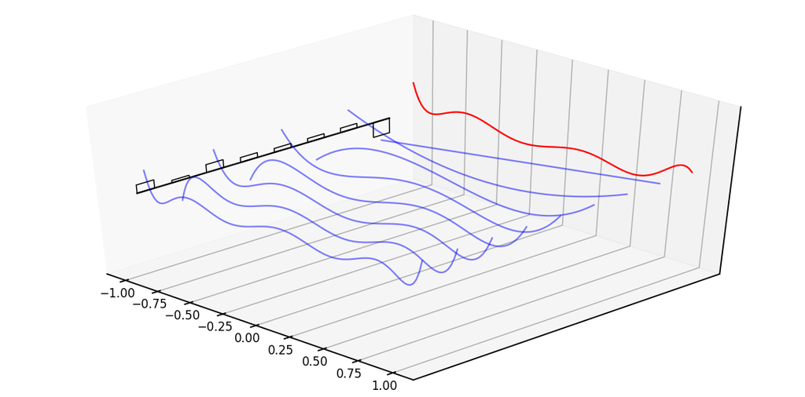

```python
def example_legendre(N=8):
    u = (np.random.rand(N) - 0.5) * 2
    t = np.linspace(-1, 1, 100)
    x = numpy.polynomial.legendre.Legendre(u)(t)
```